# Regression_ analysis

Ivan Derkachev

2024-02-07

## Проверка датасета

### Проверка на пропущенные значения

```
## Пропущеннных значений нет
```

### Проверка на выбросы (1.5 IQR)

Бросается в глаза наличие двух значений “9999” в переменной PAD680. Удалим их. Остальные перменные Будут проанализированы позже, после составления датафрейма.

### Удаление значений

# Задание 1.

Оценка физической активности респондентов

**Для оценки физической активности использованы следующие параметры:**

1. PAQ605 - Vigorous work activity
2. PAQ610 - Number of days vigorous work
3. PAD615 - Minutes vigorous-intensity work
4. PAQ620 - Moderate work activity
5. PAQ625 - Number of days moderate work
6. PAD630 - Minutes moderate-intensity work
7. PAQ635 - Walk or bicycle
8. PAQ640 - Number of days walk or bicycle
9. PAD645 - Minutes walk/bicycle for transportation
10. PAQ650 - Vigorous recreational activities
11. PAQ655 - Days vigorous recreational activities
12. PAD660 - Minutes vigorous recreational activities
13. PAQ665 - Moderate recreational activities
14. PAQ670 - Days moderate recreational activities
15. PAD675 - Minutes moderate recreational activities
16. PAD680 - Minutes sedentary activity

**Для оценки физической активности респондентов выполнялся перевод времени активности в метаболические эквиваленты активности в неделю (MET).**

*Использована литература: Haskell WL, Lee IM, Pate RR, et al. Physical activity and public health: updated recommendation for adults from the American College of Sports Medicine and the American Heart Association. Med Sci Sports Exerc. 2007;39(8):1423-1434. doi:10.1249/mss.0b013e3180616b27*

**Значения МЕТ:**

1. Сидячая активность = 1
2. Пешая ходьба или катание на велосипеде = (3+6) / 2 = 4.5
3. Умеренная активность = 5
4. Высокая активность = 8

*Есть ли у вас предварительные предположения относительно того, каким образом выбранный вами пока затель может быть ассоциирован с гликированным гемоглобином?*

Основная гипотеза заключается в том, что физическая активность, измеряемая с помощью MET, влияет на уровень гликированного гемоглобина через механизмы, включающие снижение инсулинорезистентности и поддержание нормального уровня глюкозы в крови.

# Задание 2.

Ковариаты показателей, включенных в модель для коррекции эффекта физической активности в отношении гликированного гемоглобина

**Ковариаты для коррекции:**

1. Age (количесвтенная переменная RIDAGEYR)
2. Sex (категориальная переменная RIAGENDR). Две категории: 1 - Male, 2 - Female
3. Race (категориальная переменная RIDRETH3). Шесть категорий: 1 - Mexican American, 2 - Other Hispanic, 3 - Non-Hispanic White, 4 - Non-Hispanic Black, 6 - Non-Hispanic Asian, 7 - Other Race - Including Multi-Racial
4. Education (категориальная переменная DMDEDUC2. Пять категорий: 1 - Less than 9th grade, 2 - 9-11th grade (Includes 12th grade with no diploma), 3 - High school graduate/GED or equivalent, 4 - Some college or AA degree, 5 - College graduate or above)
5. Family income (катогриальная переменная INDFMIN2). Двенадцать категорий: 1 - 0 to 4,999, 2 - 5,000 to 9,999, 3 - 10,000 to 14,999, 4 - 15,000 to 19,999, 5 - 20,000 to 24,999, 6 - 25,000 to 34,999, 7 - 35,000 to 44,999, 8 - 45,000 to 54,999, 9 - 55,000 to 64,999, 10 - 65,000 to 74,999, 11 - 75,000 to 99,999, 12 - 100,000 and Over.
6. Comorbidities (категориальные переменные: MCQ010, MCQ035, MCQ160c, MCQ160b, MCQ160e, MCQ160f, MCQ160m, MCQ170m, MCQ160o, MCQ220, BPQ020, DIQ010). Две категории: 1 - Yes, 2 - No
7. Smoking (категориальная переменная SMQ040). Три категории: 1 - Every day, 2 - Some days, 3 - Not at all

## Бонусное задание.

*Для представленного DAG’а укажите роль каждого показателя по отношениюкизучаемой ассоциации между физической активностью и гликированным гемоглобином (конфаундеры (в том числе proxy конфаундеры), коллайдеры, медиаторы)*

**Ответ:** Age - конфаундер, Comorbidities - конфаундер, Education - конфаундер, Family income - конфаундер, Race - конфаундер, Sex - конфаундер, Smoking - proxy конфаундер, Blood pressure - коллайдер, Diabetic medication - коллайдер, Marital status - parent exposure, BMI - медиатор.

# Задание 3.

Эксплораторный анализ

| **Characteristic** | **N = 914** |
| --- | --- |
| Age |  |
| N Non-missing | 914 |
| Mean (SD) | 55 (16) |
| Median (Q1-Q3) | 56 (45-67) |
| Min-Max | 20-80 |
| Sex |  |
| Female | 377 (41%) |
| Male | 537 (59%) |
| Race |  |
| Mexican_American | 101 (11%) |
| Other_Hispanic | 74 (8.1%) |
| Non-Hispanic_White | 462 (51%) |
| Non-Hispanic_Black | 175 (19%) |
| Non-Hispanic_Asian | 78 (8.5%) |
| Other_Race | 24 (2.6%) |
| Education |  |
| Less_9th-grade | 54 (5.9%) |
| 9-11th_grade | 118 (13%) |
| High_school_graduate/GED | 203 (22%) |
| Some_college | 296 (32%) |
| College_graduate_or_above | 243 (27%) |
| Family_income |  |
| 0-4,999 | 23 (2.5%) |
| 5,000-9,999 | 36 (3.9%) |
| 10,000-14,999 | 69 (7.5%) |
| 15,000-19,999 | 77 (8.4%) |
| 20,000-24,999 | 73 (8.0%) |
| 25,000-34,999 | 104 (11%) |
| 35,000-44,999 | 100 (11%) |
| 45,000-54,999 | 78 (8.5%) |
| 55,000-64,999 | 53 (5.8%) |
| 65,000-74,999 | 49 (5.4%) |
| 75,000-99,999 | 73 (8.0%) |
| 100,000-Over | 179 (20%) |
| Comorbidities | 579 (63%) |
| Smoking |  |
| Every_day | 132 (14%) |
| Some_days | 31 (3.4%) |
| Not_at_all | 751 (82%) |
| Total_MET |  |
| N Non-missing | 914 |
| Mean (SD) | 3,797 (5,338) |
| Median (Q1-Q3) | 1,560 (660-4,500) |
| Min-Max | 30-34,890 |
| Glycohemoglobin |  |
| N Non-missing | 914 |
| Mean (SD) | 5.80 (1.04) |
| Median (Q1-Q3) | 5.60 (5.30-5.90) |
| Min-Max | 4.20-13.90 |

### Факторные переменные

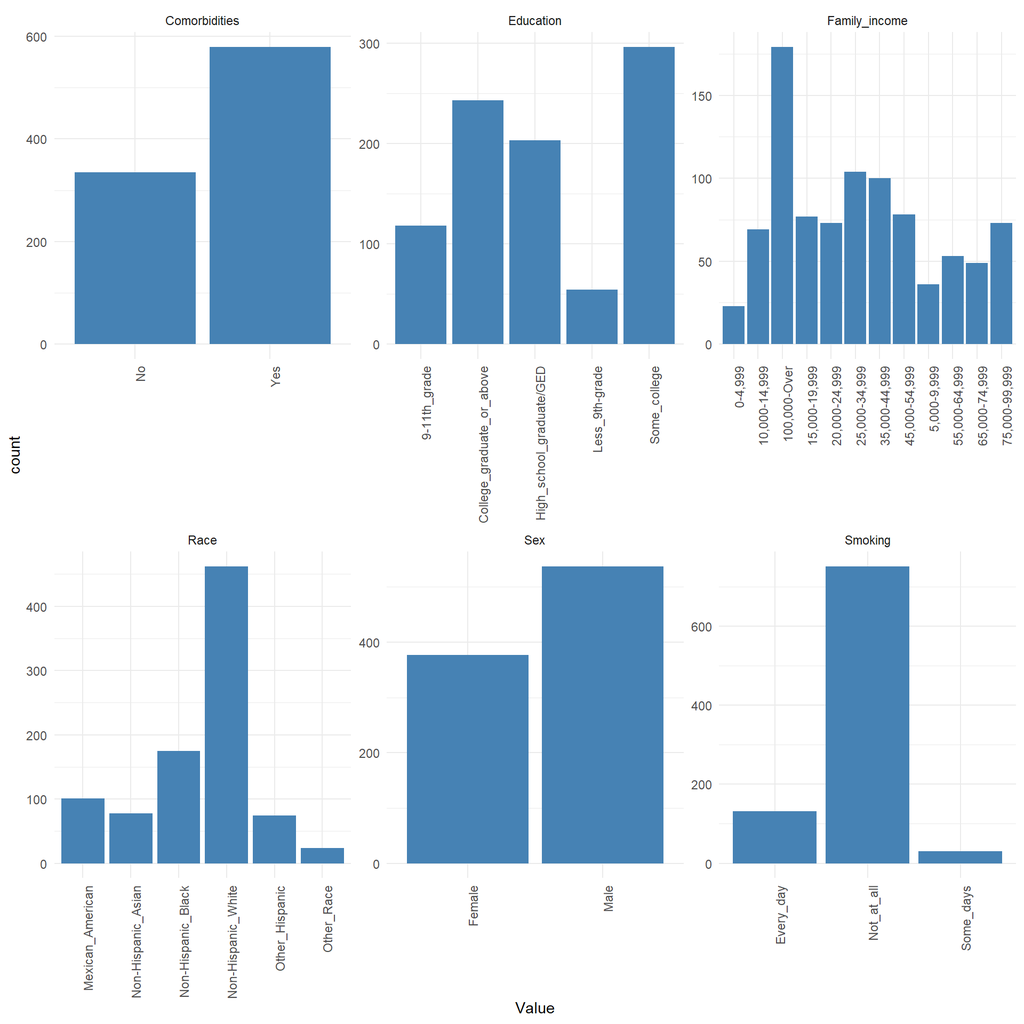

### Числовые переменные

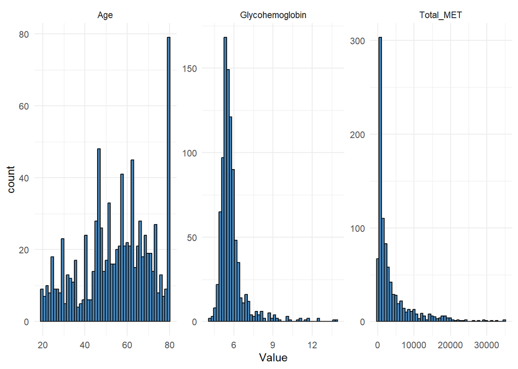

**Выводы:**  
1. В выборке преобладают взрослые люди старше 40 лет, много 80-летних относительно общего числа.  
2. В выборке больше мужчин, чем женщин  
3. В выборке преобладает раса Non-Hispanic White, т.е. неиспаноязычное белое население США  
4. В выборке преобладает люди с годовым заработком больше 100 тысяч в год.  
5. В выборке преобладают некурящие люди.  
6. Большая часть значений гликированного гемоглобина находится в пределах нормы (4 - 5.7% (до 6.5% по некоторым данным)). Однако есть много значений правее нормы.  
6. Распределение переменной Total_MET далеко от нормального.

Если попытаться построить модель по исходным данным допущения линейной регрессии ожидаемо не выполняются.

```
##
## Call:
## lm(formula = Glycohemoglobin ~ Total_MET, data = data)
##
## Residuals:
##     Min      1Q  Median      3Q     Max
## -1.6108 -0.5097 -0.2110  0.1161  8.0892
##
## Coefficients:
##               Estimate Std. Error t value Pr(>|t|)
## (Intercept)  5.812e+00  4.208e-02 138.108   <2e-16 ***
## Total_MET   -2.393e-06  6.426e-06  -0.372     0.71
## ---
## Signif. codes:  0 '***' 0.001 '**' 0.01 '*' 0.05 '.' 0.1 ' ' 1
##
## Residual standard error: 1.037 on 912 degrees of freedom
## Multiple R-squared:  0.000152,   Adjusted R-squared:  -0.0009443
## F-statistic: 0.1386 on 1 and 912 DF,  p-value: 0.7097
```

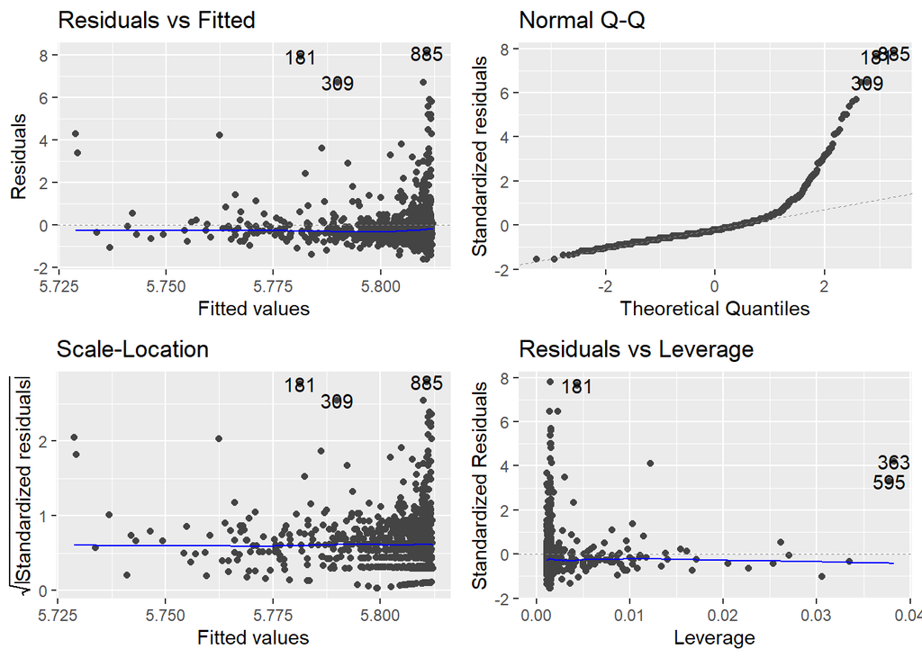

### Удаление выбросов

Для обнаружения выбросов использовался метод 1.5 IQR. Также В выборке присутсвует много 80-летних. Для того, чтобы выборка была репрезентативна для всей популяции, уберем их из данных.

### Повторный анализ

| **Characteristic** | **N = 685** |
| --- | --- |
| Age |  |
| N Non-missing | 685 |
| Mean (SD) | 53 (15) |
| Median (Q1-Q3) | 55 (44-65) |
| Min-Max | 20-79 |
| Total_MET |  |
| N Non-missing | 685 |
| Mean (SD) | 2,437 (2,442) |
| Median (Q1-Q3) | 1,440 (630-3,480) |
| Min-Max | 30-10,260 |
| Glycohemoglobin |  |
| N Non-missing | 685 |
| Mean (SD) | 5.54 (0.44) |
| Median (Q1-Q3) | 5.50 (5.30-5.80) |
| Min-Max | 4.40-6.80 |
| Sex |  |
| Female | 288 (42%) |
| Male | 397 (58%) |
| Race |  |
| Mexican_American | 73 (11%) |
| Other_Hispanic | 56 (8.2%) |
| Non-Hispanic_White | 328 (48%) |
| Non-Hispanic_Black | 138 (20%) |
| Non-Hispanic_Asian | 70 (10%) |
| Other_Race | 20 (2.9%) |
| Education |  |
| Less_9th-grade | 43 (6.3%) |
| 9-11th_grade | 81 (12%) |
| High_school_graduate/GED | 138 (20%) |
| Some_college | 227 (33%) |
| College_graduate_or_above | 196 (29%) |
| Family_income |  |
| 0-4,999 | 19 (2.8%) |
| 5,000-9,999 | 26 (3.8%) |
| 10,000-14,999 | 51 (7.4%) |
| 15,000-19,999 | 59 (8.6%) |
| 20,000-24,999 | 50 (7.3%) |
| 25,000-34,999 | 71 (10%) |
| 35,000-44,999 | 71 (10%) |
| 45,000-54,999 | 51 (7.4%) |
| 55,000-64,999 | 41 (6.0%) |
| 65,000-74,999 | 36 (5.3%) |
| 75,000-99,999 | 60 (8.8%) |
| 100,000-Over | 150 (22%) |
| Comorbidities | 402 (59%) |
| Smoking |  |
| Every_day | 98 (14%) |
| Some_days | 24 (3.5%) |
| Not_at_all | 563 (82%) |

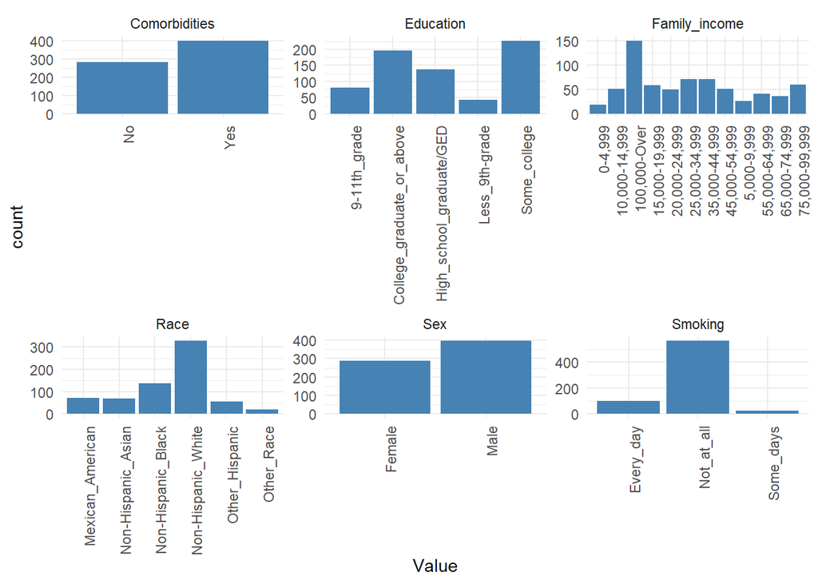

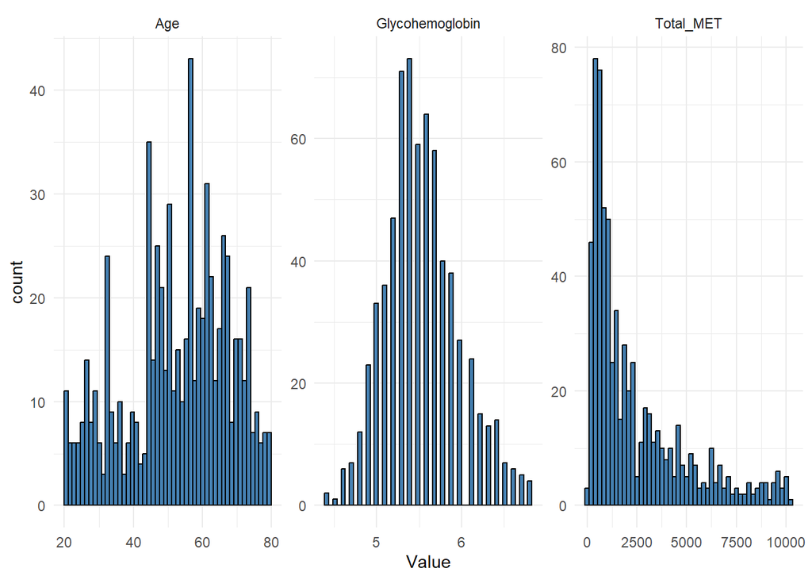

Теперь нужно преобразовать данные.

Если попытаться построить модель по исходным данным допущения линейной регрессии ожидаемо не выполняются.

```
##
## Call:
## lm(formula = Glycohemoglobin ~ Total_MET, data = data_cleaned)
##
## Residuals:
##      Min       1Q   Median       3Q      Max
## -1.17838 -0.27437 -0.04826  0.25074  1.25074
##
## Coefficients:
##               Estimate Std. Error t value Pr(>|t|)
## (Intercept)  5.582e+00  2.353e-02 237.252   <2e-16 ***
## Total_MET   -1.674e-05  6.822e-06  -2.453   0.0144 *
## ---
## Signif. codes:  0 '***' 0.001 '**' 0.01 '*' 0.05 '.' 0.1 ' ' 1
##
## Residual standard error: 0.4357 on 683 degrees of freedom
## Multiple R-squared:  0.008736,   Adjusted R-squared:  0.007284
## F-statistic: 6.019 on 1 and 683 DF,  p-value: 0.0144
```

```
##
## Call:
## lm(formula = Glycohemoglobin ~ Total_MET, data = data_cleaned)
##
## Coefficients:
## (Intercept)    Total_MET
##   5.582e+00   -1.674e-05
##
##
## ASSESSMENT OF THE LINEAR MODEL ASSUMPTIONS
## USING THE GLOBAL TEST ON 4 DEGREES-OF-FREEDOM:
## Level of Significance =  0.05
##
## Call:
##  gvlma(x = wrong_model)
##
##                       Value   p-value                   Decision
## Global Stat        14.72473 0.0053075 Assumptions NOT satisfied!
## Skewness           12.48237 0.0004108 Assumptions NOT satisfied!
## Kurtosis            0.10163 0.7498812    Assumptions acceptable.
## Link Function       2.05085 0.1521215    Assumptions acceptable.
## Heteroscedasticity  0.08989 0.7643230    Assumptions acceptable.
```

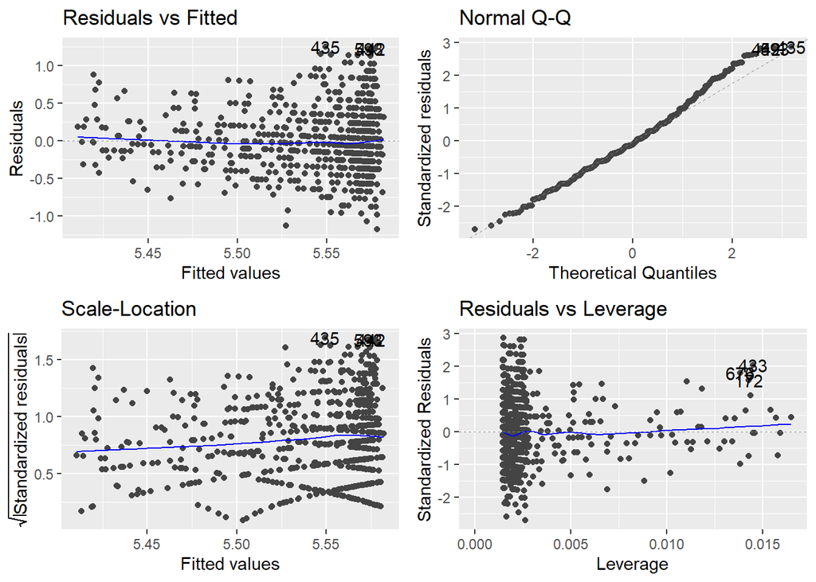

### Преобразование числовых переменных

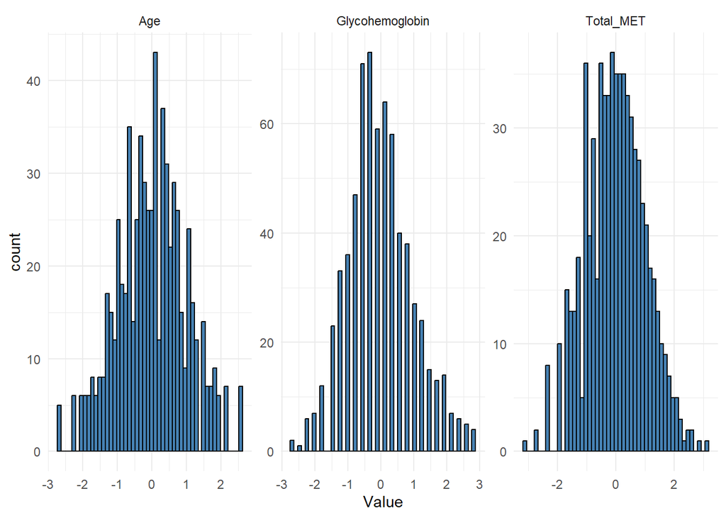

# Задание 4.

Оценка моделей для зависимости гликированного гемоглобина от выбранного вами показателя физической активности без ковариат и с ними

## Модель без ковариат

**Оценка модели:**

## Оценка модели без ковариат

### Summary, Residuals vs Fitted, QQ, scale-location plots

```
##
## Call:
## lm(formula = Glycohemoglobin ~ Total_MET, data = data_final)
##
## Residuals:
##      Min       1Q   Median       3Q      Max
## -2.92126 -0.64132 -0.07023  0.59130  2.78481
##
## Coefficients:
##               Estimate Std. Error t value Pr(>|t|)
## (Intercept)  5.867e-05  3.806e-02   0.002   0.9988
## Total_MET   -9.620e-02  3.816e-02  -2.521   0.0119 *
## ---
## Signif. codes:  0 '***' 0.001 '**' 0.01 '*' 0.05 '.' 0.1 ' ' 1
##
## Residual standard error: 0.9961 on 683 degrees of freedom
## Multiple R-squared:  0.009221,   Adjusted R-squared:  0.007771
## F-statistic: 6.357 on 1 and 683 DF,  p-value: 0.01192
```

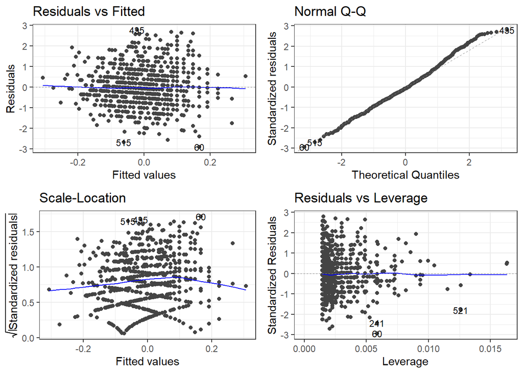

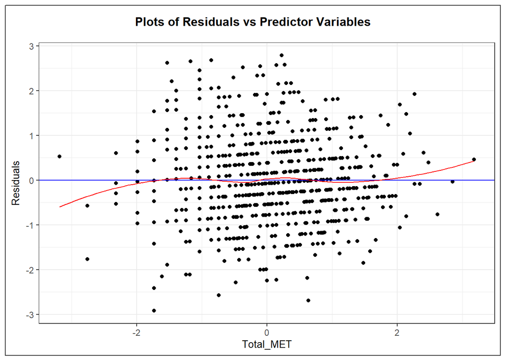

### Residuals-Leverage, COOK’s D plots

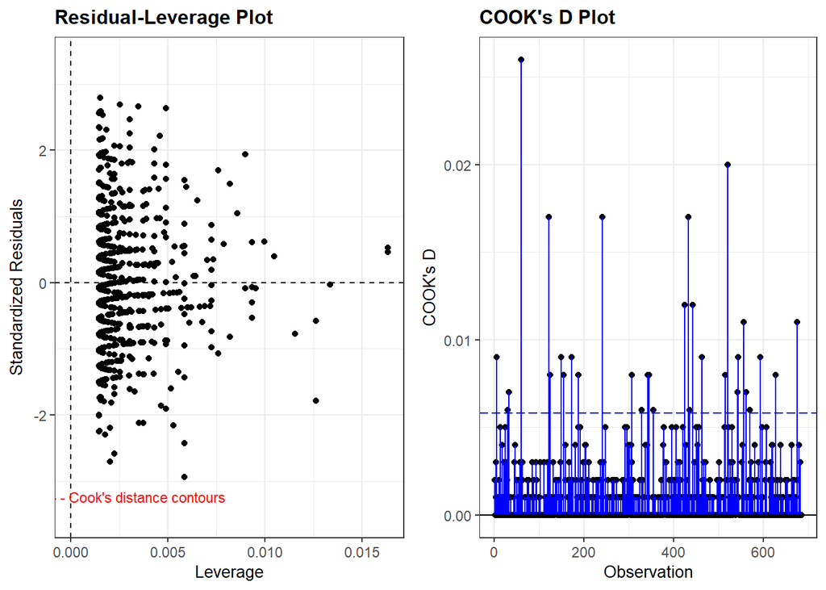

### Табличное представления оценок и доверительные интервалы

```
## # A tibble: 2 × 7
##   term          estimate std.error statistic p.value conf.low conf.high
##   <chr>            <dbl>     <dbl>     <dbl>   <dbl>    <dbl>     <dbl>
## 1 (Intercept)  0.0000587    0.0381   0.00154  0.999   -0.0747    0.0748
## 2 Total_MET   -0.0962       0.0382  -2.52     0.0119  -0.171    -0.0213
```

## Модель с ковариатами

## Оценка модели с ковариатами

### Summary, Residuals vs Fitted, QQ, scale-location plots

```
##
## Call:
## lm(formula = Glycohemoglobin ~ Total_MET + Sex + Age + Race +
##     Education + Comorbidities + Smoking, data = data_final)
##
## Residuals:
##      Min       1Q   Median       3Q      Max
## -3.14443 -0.55419 -0.03957  0.53502  2.75961
##
## Coefficients:
##                                    Estimate Std. Error t value Pr(>|t|)
## (Intercept)                         0.10284    0.18723   0.549 0.583013
## Total_MET                           0.01030    0.03688   0.279 0.780153
## SexMale                             0.01300    0.07705   0.169 0.866030
## Age                                 0.27894    0.04101   6.802 2.30e-11 ***
## RaceOther_Hispanic                  0.15411    0.16751   0.920 0.357899
## RaceNon-Hispanic_White             -0.09695    0.13038  -0.744 0.457362
## RaceNon-Hispanic_Black              0.37454    0.14073   2.661 0.007967 **
## RaceNon-Hispanic_Asian              0.54376    0.16311   3.334 0.000904 ***
## RaceOther_Race                     -0.00521    0.23790  -0.022 0.982533
## Education9-11th_grade              -0.32301    0.17659  -1.829 0.067820 .
## EducationHigh_school_graduate/GED  -0.45855    0.16897  -2.714 0.006822 **
## EducationSome_college              -0.47818    0.16578  -2.885 0.004046 **
## EducationCollege_graduate_or_above -0.73615    0.17050  -4.318 1.82e-05 ***
## ComorbiditiesYes                    0.18848    0.07751   2.432 0.015291 *
## SmokingSome_days                    0.15827    0.20824   0.760 0.447510
## SmokingNot_at_all                   0.21437    0.10434   2.055 0.040310 *
## ---
## Signif. codes:  0 '***' 0.001 '**' 0.01 '*' 0.05 '.' 0.1 ' ' 1
##
## Residual standard error: 0.9054 on 669 degrees of freedom
## Multiple R-squared:  0.1983, Adjusted R-squared:  0.1803
## F-statistic: 11.03 on 15 and 669 DF,  p-value: < 2.2e-16
```

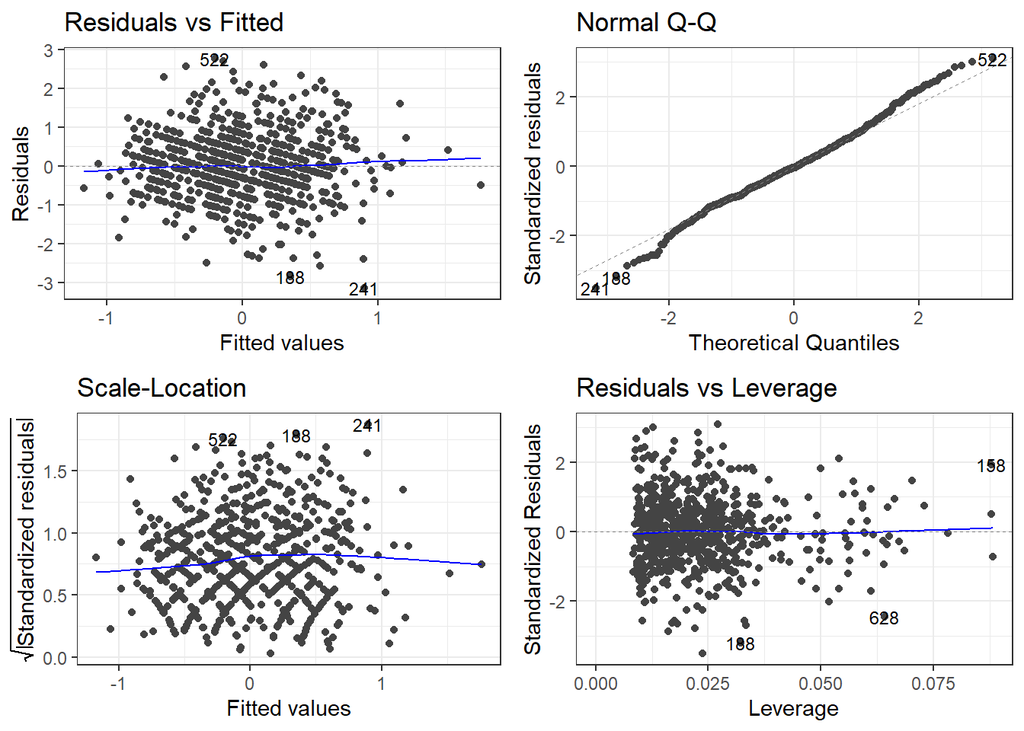

[figure not shown]

### Residuals-Leverage, COOK’s D plots

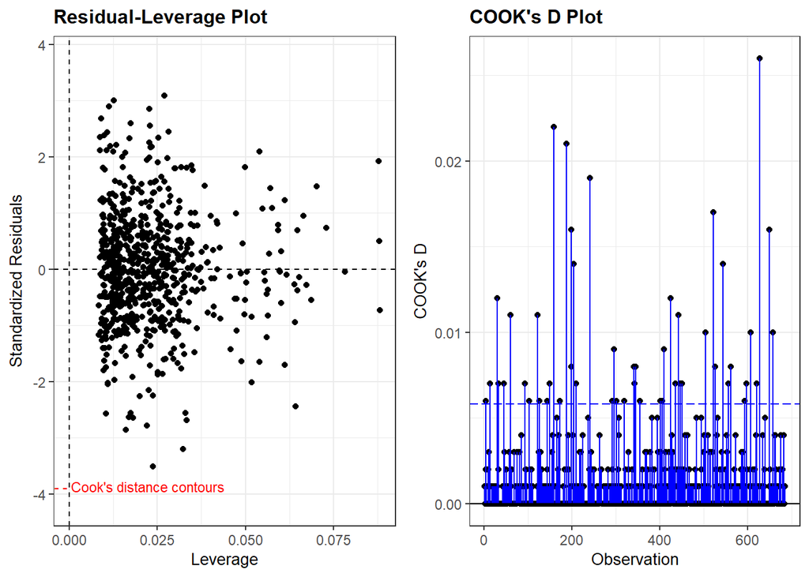

### Оценка мультиколлинеарности.

```
##                   GVIF Df GVIF^(1/(2*Df))
## Total_MET     1.130956  1        1.063464
## Sex           1.208872  1        1.099487
## Age           1.388672  1        1.178419
## Race          1.401012  5        1.034294
## Education     1.457759  4        1.048240
## Comorbidities 1.217266  1        1.103298
## Smoking       1.131675  2        1.031408
```

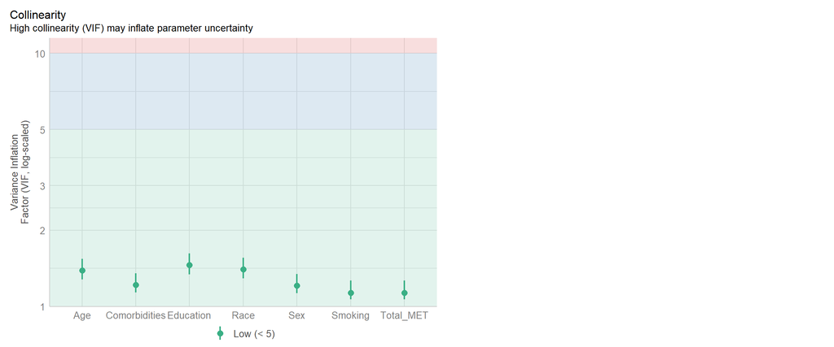

### Табличное представления оценок и доверительные интервалы

```
## # A tibble: 16 × 7
##    term                 estimate std.error statistic  p.value conf.low conf.high
##    <chr>                   <dbl>     <dbl>     <dbl>    <dbl>    <dbl>     <dbl>
##  1 (Intercept)           0.103      0.187     0.549  5.83e- 1 -0.265      0.470
##  2 Total_MET             0.0103     0.0369    0.279  7.80e- 1 -0.0621     0.0827
##  3 SexMale               0.0130     0.0770    0.169  8.66e- 1 -0.138      0.164
##  4 Age                   0.279      0.0410    6.80   2.30e-11  0.198      0.359
##  5 RaceOther_Hispanic    0.154      0.168     0.920  3.58e- 1 -0.175      0.483
##  6 RaceNon-Hispanic_Wh… -0.0970     0.130    -0.744  4.57e- 1 -0.353      0.159
##  7 RaceNon-Hispanic_Bl…  0.375      0.141     2.66   7.97e- 3  0.0982     0.651
##  8 RaceNon-Hispanic_As…  0.544      0.163     3.33   9.04e- 4  0.223      0.864
##  9 RaceOther_Race       -0.00521    0.238    -0.0219 9.83e- 1 -0.472      0.462
## 10 Education9-11th_gra… -0.323      0.177    -1.83   6.78e- 2 -0.670      0.0237
## 11 EducationHigh_schoo… -0.459      0.169    -2.71   6.82e- 3 -0.790     -0.127
## 12 EducationSome_colle… -0.478      0.166    -2.88   4.05e- 3 -0.804     -0.153
## 13 EducationCollege_gr… -0.736      0.170    -4.32   1.82e- 5 -1.07      -0.401
## 14 ComorbiditiesYes      0.188      0.0775    2.43   1.53e- 2  0.0363     0.341
## 15 SmokingSome_days      0.158      0.208     0.760  4.48e- 1 -0.251      0.567
## 16 SmokingNot_at_all     0.214      0.104     2.05   4.03e- 2  0.00950    0.419
```

**Выводы:**  
1. Допущения линейной регрессии в целом соблюдены.Не наблюдается сильного смещения остатков. Распределение остатков выглядит относительно симметричным. Однако, наличие некоторых выбросов может указывать на то, что модель не полностью учитывает все особенности данных. VIF < 2 - мультиколлинеарности нет.

Коэффиценты модели:  
1. Возраст (Age): Возраст имеет сильное положительное влияние на уровень гликогемоглобина (p-value < 0.001). Это означает, что с увеличением возраста уровень гликогемоглобина увеличивается.  
2. Раса (Race):  
Non-Hispanic Black и Non-Hispanic Asian имеют значимое положительное влияние на уровень гликогемоглобина (p-value < 0.01 и p-value < 0.001 соответственно). Другие расовые группы не показали значимого влияния. 3. Образование (Education):  
Все уровни образования, начиная с “High school graduate/GED” и выше, имеют значимое отрицательное влияние на уровень гликогемоглобина. Это означает, что более высокий уровень образования связан с более низким уровнем гликогемоглобина.  
4. Наличие сопутствующих заболеваний (Comorbidities): Наличие сопутствующих заболеваний положительно влияет на уровень гликогемоглобина (p-value < 0.05).

# Задание 5.

Представьте результаты оценки модели без ковариат и с ковариатами в виде точечной и интервальной оценки эффекта физической активности. Дайте им словесную интерпретацию. Какие выводы мы можем сделать, исходя из точечной оценки? А из интервальной? Как вы думаете, можно ли считать эффект клинически значимым? Если затрудняетесь с ответом, что бы вам помогло дать ответ на этот вопрос?

В модели с ковариатами эффект слишком мал и статистически незначим, поэтому его клиническая значимость сомнительна. Это подчеркивает важность учета confounding факторов (смешивающих переменных) при оценке эффектов.

# Задание 6.

Проверьте гипотезу об отсутствии ассоциации между физической активностью и гликированным гемоглобином. Сделайте выводы по полученным результатам.

*Выводы*: Исходя из результатов задания 5 нет оснований отвергнуть нулевую гипотезу об отсутствии ассоциации между гликированным гемоглобином и уровнем физической активности, выраженной в метаболических коэффициентах.

# Задание 7.

Является ли пол модификатором эффекта физической активности в отношении гликированного гемоглобина? Если да, каков эффект для мужчин и женщин и насколько он отличается между ними?

```
##
## Call:
## lm(formula = Glycohemoglobin ~ Total_MET * Sex + Age + Race +
##     Education + Comorbidities + Smoking, data = data_final)
##
## Residuals:
##      Min       1Q   Median       3Q      Max
## -3.08072 -0.55639 -0.03278  0.54538  2.75224
##
## Coefficients:
##                                     Estimate Std. Error t value Pr(>|t|)
## (Intercept)                         0.078397   0.188206   0.417 0.677143
## Total_MET                          -0.045232   0.058236  -0.777 0.437612
## SexMale                             0.022524   0.077406   0.291 0.771157
## Age                                 0.282230   0.041083   6.870 1.47e-11 ***
## RaceOther_Hispanic                  0.154878   0.167449   0.925 0.355337
## RaceNon-Hispanic_White             -0.095048   0.130337  -0.729 0.466107
## RaceNon-Hispanic_Black              0.377209   0.140690   2.681 0.007518 **
## RaceNon-Hispanic_Asian              0.551797   0.163178   3.382 0.000763 ***
## RaceOther_Race                     -0.007903   0.237822  -0.033 0.973501
## Education9-11th_grade              -0.314328   0.176661  -1.779 0.075651 .
## EducationHigh_school_graduate/GED  -0.453662   0.168949  -2.685 0.007429 **
## EducationSome_college              -0.469228   0.165872  -2.829 0.004811 **
## EducationCollege_graduate_or_above -0.719054   0.170998  -4.205 2.97e-05 ***
## ComorbiditiesYes                    0.185327   0.077522   2.391 0.017095 *
## SmokingSome_days                    0.153424   0.208201   0.737 0.461439
## SmokingNot_at_all                   0.212572   0.104308   2.038 0.041951 *
## Total_MET:SexMale                   0.090972   0.073853   1.232 0.218457
## ---
## Signif. codes:  0 '***' 0.001 '**' 0.01 '*' 0.05 '.' 0.1 ' ' 1
##
## Residual standard error: 0.905 on 668 degrees of freedom
## Multiple R-squared:  0.2001, Adjusted R-squared:  0.1809
## F-statistic: 10.44 on 16 and 668 DF,  p-value: < 2.2e-16
```

## Диагностика модели

```
##
## Call:
## lm(formula = Glycohemoglobin ~ Total_MET * Sex + Age + Race +
##     Education + Comorbidities + Smoking, data = data_final)
##
## Residuals:
##      Min       1Q   Median       3Q      Max
## -3.08072 -0.55639 -0.03278  0.54538  2.75224
##
## Coefficients:
##                                     Estimate Std. Error t value Pr(>|t|)
## (Intercept)                         0.078397   0.188206   0.417 0.677143
## Total_MET                          -0.045232   0.058236  -0.777 0.437612
## SexMale                             0.022524   0.077406   0.291 0.771157
## Age                                 0.282230   0.041083   6.870 1.47e-11 ***
## RaceOther_Hispanic                  0.154878   0.167449   0.925 0.355337
## RaceNon-Hispanic_White             -0.095048   0.130337  -0.729 0.466107
## RaceNon-Hispanic_Black              0.377209   0.140690   2.681 0.007518 **
## RaceNon-Hispanic_Asian              0.551797   0.163178   3.382 0.000763 ***
## RaceOther_Race                     -0.007903   0.237822  -0.033 0.973501
## Education9-11th_grade              -0.314328   0.176661  -1.779 0.075651 .
## EducationHigh_school_graduate/GED  -0.453662   0.168949  -2.685 0.007429 **
## EducationSome_college              -0.469228   0.165872  -2.829 0.004811 **
## EducationCollege_graduate_or_above -0.719054   0.170998  -4.205 2.97e-05 ***
## ComorbiditiesYes                    0.185327   0.077522   2.391 0.017095 *
## SmokingSome_days                    0.153424   0.208201   0.737 0.461439
## SmokingNot_at_all                   0.212572   0.104308   2.038 0.041951 *
## Total_MET:SexMale                   0.090972   0.073853   1.232 0.218457
## ---
## Signif. codes:  0 '***' 0.001 '**' 0.01 '*' 0.05 '.' 0.1 ' ' 1
##
## Residual standard error: 0.905 on 668 degrees of freedom
## Multiple R-squared:  0.2001, Adjusted R-squared:  0.1809
## F-statistic: 10.44 on 16 and 668 DF,  p-value: < 2.2e-16
```

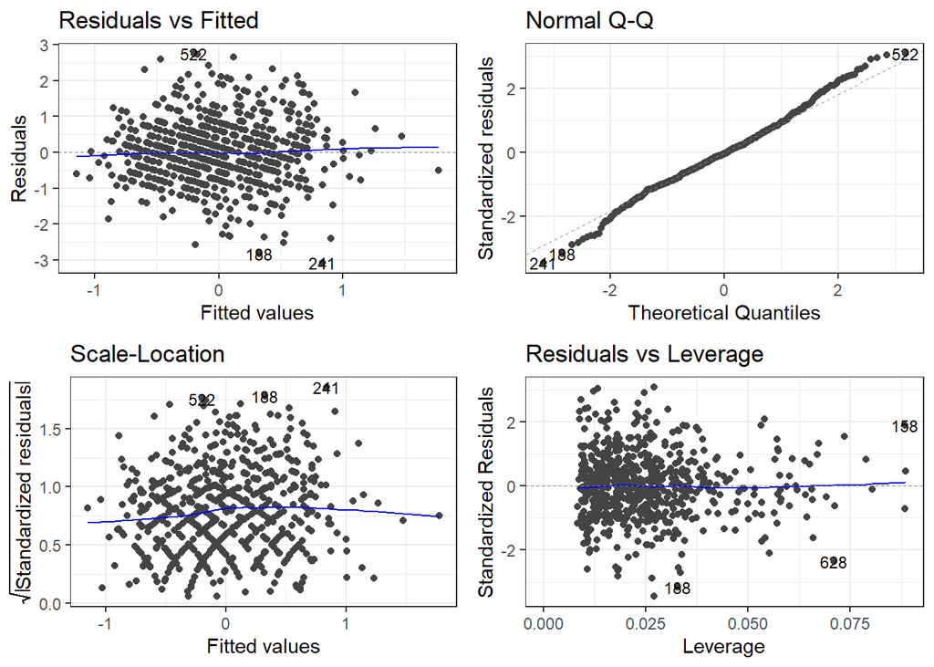

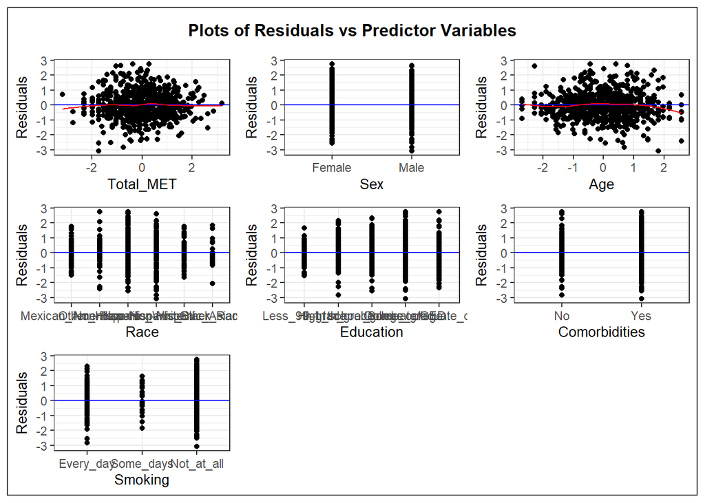

```
## # A tibble: 17 × 7
##    term                 estimate std.error statistic  p.value conf.low conf.high
##    <chr>                   <dbl>     <dbl>     <dbl>    <dbl>    <dbl>     <dbl>
##  1 (Intercept)           0.0784     0.188     0.417  6.77e- 1 -0.291      0.448
##  2 Total_MET            -0.0452     0.0582   -0.777  4.38e- 1 -0.160      0.0691
##  3 SexMale               0.0225     0.0774    0.291  7.71e- 1 -0.129      0.175
##  4 Age                   0.282      0.0411    6.87   1.47e-11  0.202      0.363
##  5 RaceOther_Hispanic    0.155      0.167     0.925  3.55e- 1 -0.174      0.484
##  6 RaceNon-Hispanic_Wh… -0.0950     0.130    -0.729  4.66e- 1 -0.351      0.161
##  7 RaceNon-Hispanic_Bl…  0.377      0.141     2.68   7.52e- 3  0.101      0.653
##  8 RaceNon-Hispanic_As…  0.552      0.163     3.38   7.63e- 4  0.231      0.872
##  9 RaceOther_Race       -0.00790    0.238    -0.0332 9.74e- 1 -0.475      0.459
## 10 Education9-11th_gra… -0.314      0.177    -1.78   7.57e- 2 -0.661      0.0326
## 11 EducationHigh_schoo… -0.454      0.169    -2.69   7.43e- 3 -0.785     -0.122
## 12 EducationSome_colle… -0.469      0.166    -2.83   4.81e- 3 -0.795     -0.144
## 13 EducationCollege_gr… -0.719      0.171    -4.21   2.97e- 5 -1.05      -0.383
## 14 ComorbiditiesYes      0.185      0.0775    2.39   1.71e- 2  0.0331     0.338
## 15 SmokingSome_days      0.153      0.208     0.737  4.61e- 1 -0.255      0.562
## 16 SmokingNot_at_all     0.213      0.104     2.04   4.20e- 2  0.00776    0.417
## 17 Total_MET:SexMale     0.0910     0.0739    1.23   2.18e- 1 -0.0540     0.236
```

**Вывод:** Пол не является статистически значимым модификатором эффекта физической активности в отношении гликированного гемоглобина.

# Задание 8.

Соответствуют ли полученные вами результаты вашему исходному предположению? Как меняется оценка эффекта физической активности при добавлении ковариат в модель и почему?

**Ответ**: При работе с моделью без ковариат, было обнаружено слабое, но статистически значимое отрицательное влияние физической активности в отношении гликированного гемоглобина. Полученные в данной модели результаты соответствуют исходному предположению: физическая активность влияет на уровень гликированного геомглобина. Стоит отметить, что коэффициент детерминации (R2) очень низкий (0.0087), что говорит о том, что объясненная дисперсия уровня HbA1c за счет одной только физической активности крайне мала.

Однако при добавлении в модель ковариат влияние физической активности на уровень HbA1c оказалось статистически незначимым. При этом наблюдается изменение коэффициента.

Это изменение можно объяснить тем, что переменные, такие как возраст, образование, раса и другие, могут быть конфундерами, которые влияют как на физическую активность, так и на уровень HbA1c. Например, люди старшего возраста имеют более низкую физическую активность и более высокий уровень HbA1c. Образованные люди могут вести более здоровый образ жизни, что может повлиять на оба показателя.

# Бонусное задание

## Оценка модели с BMI

### Summary, Residuals vs Fitted, QQ, scale-location plots

```
##
## Call:
## lm(formula = Glycohemoglobin ~ Total_MET + Sex + Age + Race +
##     Education + Comorbidities + Smoking + BMI, data = data_cleaned_BMI)
##
## Residuals:
##      Min       1Q   Median       3Q      Max
## -1.46546 -0.23237  0.00059  0.21467  1.26444
##
## Coefficients:
##                                      Estimate Std. Error t value Pr(>|t|)
## (Intercept)                         4.710e+00  1.267e-01  37.184  < 2e-16 ***
## Total_MET                           3.421e-06  6.398e-06   0.535  0.59299
## SexMale                             2.803e-02  3.311e-02   0.847  0.39743
## Age                                 9.054e-03  1.171e-03   7.733 4.05e-14 ***
## RaceOther_Hispanic                  8.003e-02  7.213e-02   1.110  0.26761
## RaceNon-Hispanic_White             -2.829e-02  5.595e-02  -0.506  0.61329
## RaceNon-Hispanic_Black              1.580e-01  6.058e-02   2.609  0.00930 **
## RaceNon-Hispanic_Asian              3.051e-01  7.009e-02   4.352 1.56e-05 ***
## RaceOther_Race                      7.969e-02  1.025e-01   0.777  0.43730
## Education9-11th_grade              -1.254e-01  7.518e-02  -1.668  0.09586 .
## EducationHigh_school_graduate/GED  -2.025e-01  7.220e-02  -2.804  0.00519 **
## EducationSome_college              -2.014e-01  7.041e-02  -2.860  0.00437 **
## EducationCollege_graduate_or_above -2.892e-01  7.233e-02  -3.999 7.09e-05 ***
## ComorbiditiesYes                    6.776e-02  3.328e-02   2.036  0.04217 *
## SmokingSome_days                    7.120e-02  8.750e-02   0.814  0.41614
## SmokingNot_at_all                   5.932e-02  4.458e-02   1.331  0.18377
## BMI                                 1.321e-02  2.777e-03   4.756 2.43e-06 ***
## ---
## Signif. codes:  0 '***' 0.001 '**' 0.01 '*' 0.05 '.' 0.1 ' ' 1
##
## Residual standard error: 0.3794 on 647 degrees of freedom
## Multiple R-squared:  0.2459, Adjusted R-squared:  0.2272
## F-statistic: 13.19 on 16 and 647 DF,  p-value: < 2.2e-16
```

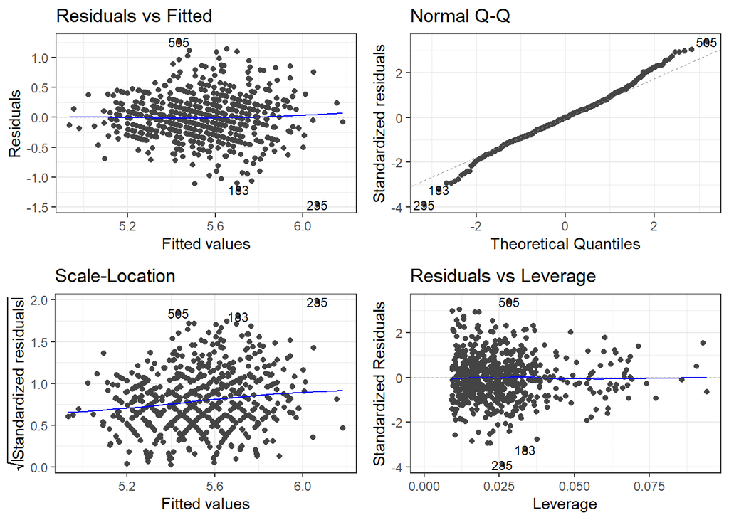

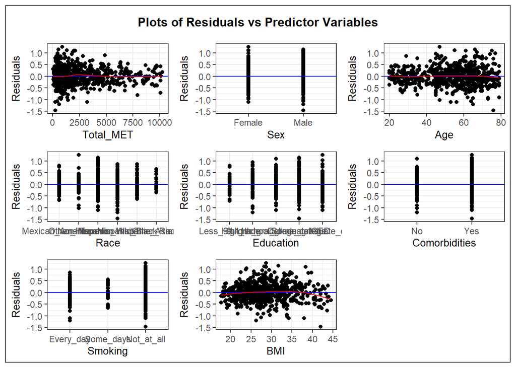

### Residuals-Leverage, COOK’s D plots

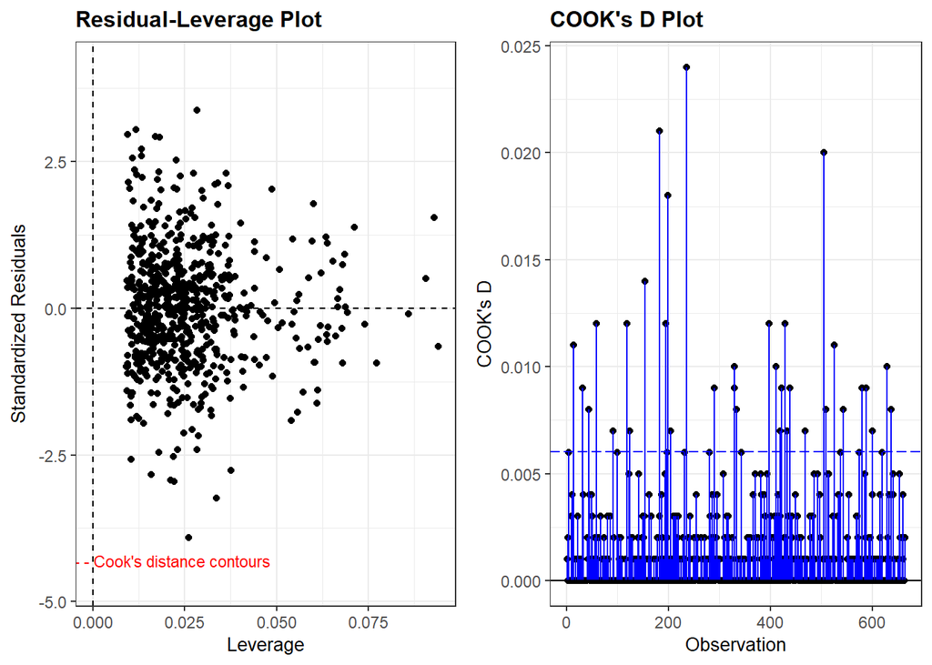

### Оценка мультиколлинеарности.

```
##                   GVIF Df GVIF^(1/(2*Df))
## Total_MET     1.119887  1        1.058247
## Sex           1.225237  1        1.106904
## Age           1.434701  1        1.197790
## Race          1.492543  5        1.040861
## Education     1.475845  4        1.049857
## Comorbidities 1.240941  1        1.113975
## Smoking       1.162878  2        1.038445
## BMI           1.105457  1        1.051407
```

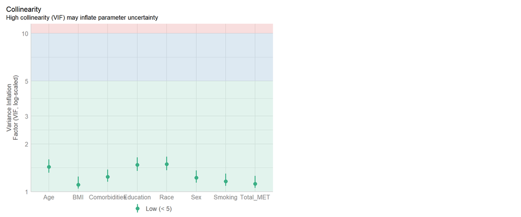

### Табличное представления оценок и доверительные интервалы

```
## # A tibble: 17 × 7
##    term                estimate std.error statistic   p.value conf.low conf.high
##    <chr>                  <dbl>     <dbl>     <dbl>     <dbl>    <dbl>     <dbl>
##  1 (Intercept)          4.71e+0   1.27e-1    37.2   9.02e-163  4.46e+0   4.96e+0
##  2 Total_MET            3.42e-6   6.40e-6     0.535 5.93e-  1 -9.14e-6   1.60e-5
##  3 SexMale              2.80e-2   3.31e-2     0.847 3.97e-  1 -3.70e-2   9.30e-2
##  4 Age                  9.05e-3   1.17e-3     7.73  4.05e- 14  6.75e-3   1.14e-2
##  5 RaceOther_Hispanic   8.00e-2   7.21e-2     1.11  2.68e-  1 -6.16e-2   2.22e-1
##  6 RaceNon-Hispanic_W… -2.83e-2   5.59e-2    -0.506 6.13e-  1 -1.38e-1   8.16e-2
##  7 RaceNon-Hispanic_B…  1.58e-1   6.06e-2     2.61  9.30e-  3  3.91e-2   2.77e-1
##  8 RaceNon-Hispanic_A…  3.05e-1   7.01e-2     4.35  1.56e-  5  1.67e-1   4.43e-1
##  9 RaceOther_Race       7.97e-2   1.03e-1     0.777 4.37e-  1 -1.22e-1   2.81e-1
## 10 Education9-11th_gr… -1.25e-1   7.52e-2    -1.67  9.59e-  2 -2.73e-1   2.22e-2
## 11 EducationHigh_scho… -2.02e-1   7.22e-2    -2.80  5.19e-  3 -3.44e-1  -6.07e-2
## 12 EducationSome_coll… -2.01e-1   7.04e-2    -2.86  4.37e-  3 -3.40e-1  -6.31e-2
## 13 EducationCollege_g… -2.89e-1   7.23e-2    -4.00  7.09e-  5 -4.31e-1  -1.47e-1
## 14 ComorbiditiesYes     6.78e-2   3.33e-2     2.04  4.22e-  2  2.41e-3   1.33e-1
## 15 SmokingSome_days     7.12e-2   8.75e-2     0.814 4.16e-  1 -1.01e-1   2.43e-1
## 16 SmokingNot_at_all    5.93e-2   4.46e-2     1.33  1.84e-  1 -2.82e-2   1.47e-1
## 17 BMI                  1.32e-2   2.78e-3     4.76  2.43e-  6  7.76e-3   1.87e-2
```